# Lecture 05: GLM and DOE

Module on Logistic Regression

# Lecture Goals

- Extend the ideas of GLM beyond binary data.
- Use Generalized Linear Modeling in a Design of Experiment setting.
- A review of DOE but with a logistic model.
  - A review of **a complete analysis**.

# Generalized Linear Models

In this module we have been working with Logistic regression and have discussed how it is a **Generalized Linear Model** (GLM). GLMs are a widely used tool in statistical analyses that bridge, or *link*, regular regression to other types of response variables. GLMs consist of two additional components compared to a standard multiple regression model:

- Family: the distribution of the response variable.
- A link function: it “links” a linear model to the response variable.

Ultimately, GLMs decompose the **deviance** (a generalization of the variance or noise or error) into two components – the part explained by the model and the unexplained part (called the Residual Deviance). Below, we summarize some of the common GLMs used in statistical analysis based on the type of response variable:

**“Normal” response** – A response variable that is quantitative and measured across the entire real line, or at least a large subset of the real line. Ideally the distribution of the response should follow a bell-curve but this technique also works well for large sample sizes and when the response is not heavily skewed or exhibits extreme tails.

- Family: Normal Distribution
- An *identity* Link is used: $f(\mu)=\mu$

This is Multiple Linear Regression.

**Binary response** – The response variable of interest is a dichotomous output (yes/no, true/false, alive/dead, pass/fail). The technique is typically called Logistic regression:

- Family: Binomial Distribution
- Link: log odds, or *logit*, link function: $f(p)=\log\left(\frac{p}{1-p}\right)$
  - The *probit* link function is used in some context

We have seen multiple cases of Logistic modeling and will see another later today.

**Count response** – The response variable of interest is a *count* (*e.g.*, the number Tropical Cyclones in the North Atlantic Ocean in a given year) and generally has *smallish* values (in the single or double digits). Normal regression fails and we typically use one of two methods: **Poisson Regression** or **Negative Binomial Regression**:

- Family: Poisson Distribution or Negative Binomial Distribution
- Link: A logarithm of the mean (“log-link”): $f(\mu) = \log(\mu)$
  - Poisson regression can be done in the `glm()` function with `family=poisson(link=log)`

When the response takes on large quantities (*i.e.*, the counts are in the hundreds or thousands) Normal regression methods tend to work well.

**Right-Skewed response** – The response variable of interest is numeric but very right skewed. We may try considering a logarithmic transformation and then performing Normal regression techniques. An alternative is to use a GLM designed for right skewed data. Common choices include **Gamma Regression** or **Inverse Gaussian Regression**:

- Family: Gamma Distribution or Inverse Gaussian Distribution
- Link: Typically a logarithm of the mean (“log-link”): $f(\mu) = \log(\mu)$ or inverse of mean $f(\mu) = 1/\mu$ is used.
  - Both can be done using the `glm()` function; for example, `family=Gamma(link="log")` or `family=inverse.gaussian(link="inverse")`.

Mathematically this is similar to performing Normal regression on a transformed response, except that likelihood and deviance measures are based on the response variable (not a transformation thereof).

# Review of a Complete Data Analysis

Before looking at one more example we briefly review the key elements of a **complete data analysis**:

- **Problem and Analysis Identification** - Identify the contextual problem of study and the analysis required to gain insight into the problem.
  - In Design of Experiments the design dictates the analysis.
  - In Observation Studies, model building techniques are used to address the problem.
- **Data Input and Munging** - Raw data is input into statistical software and perform any necessary data handling.
  - In this course we’ve used the `tidyverse` suite of tools for data processing.
- **Exploratory Data Analysis** - Explore the innerworkings of the data!
  - Graphical and Tabular explorations to gain insight into the behavior and relationships among the variables in the data.
- **Modeling and Assessment of Method** - Fit statistical models and assess their appropriateness.
  - Fit an Analysis of Variance (`aov()`), Linear Model (`lm()`) or Generalized Linear Model (`glm()`).
  - Assess its appropriateness through a residual analysis or other mechanisms (*e.g.*, in logistic regression we may look at the residual deviance).
- **Statistical Inference** - Perform the key analysis to address the contextual problem.
  - An overall model test for significance ($F$-test or $\chi^2$-test).
  - Follow-up procedures to test specific comparisons (*e.g.*, Tukey HSD, Dunnett, conditional $t$-test, reduced model $F$-test or $\chi^2$-test).
- **Overall Conclusions** - Contextual questions are addressed.
  - When possible include a visual aid (graphics) to help *tell the story*.

# Design of Experiments with GLMs

When covering categorical variables and ANCOVA in the regression module we discussed how the analysis that accompanies ANOVA is actually a special type of regression modeling. Generalized Linear Models are an extension of Regression, so it should not be much of a stretch to consider a GLM in a design of experiments setting.

## Data Description

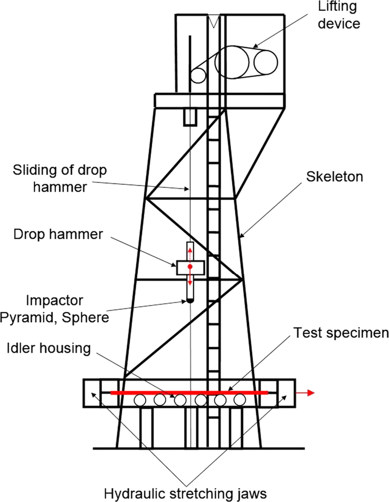

Transportation of material by means of belt conveyors is a typical method applied in various processes including mining, agriculture, and in the processing of mineral raw materials. Belt conveyors are often exposed to various impacts that can lead to damage and degradation. An experiment was conducted to test the endurance of rubber–textile conveyor belts.

In the experiment a drop hammer (82kg or 180lbs) was raised to a specified *impact height* and released falling onto a conveyor belt below (see schematic). Three different types of conveyor belts were tested: *new* belts (coded as a 1); *renovated* belts (coded as a 2); and *worn* belts (coded as a 3). Basic Newtonian physics tells us the impact height will have an effect since the energy of the hammer’s impact is a function of height (specifically, $E=mgh$ in a drop experiment, where $m$ is the mass of the hammer, $g$ is the gravitational acceleration constant [9.8 $m/s^2$], and $h$ is the height in meters) so the experimenters looked at a range of drop heights from 0.8 to 2.6 meters (2.6 to 8.5 feet). Of interest to the experimenters is whether the conveyor belt sustained severe damage during the experimental run (recorded as a 0 for no damage and 1 for severe damage). In an effort to prevent any *burn-in* or *wearing effects* of the drop hammer, the order in which belts and impact heights were tested was random.

**Sources:** Data, Concept and Image: (Andrejiova et al. 2014).

## Design Elements

Note this is a **designed experiment**. Identify all the elements of the design:

- The **Experimental Units** in this study are the conveyor belts that are tested.
- The **Factor variable** in this study is the belt type.
  - There are **three levels** of belt type.
- The impact height variable is a **covariate** term that is acting similar to a *block* effect.
  - The impact height is a quantitative **covariate** with ten unique values.
  - It is technically not a block but is acting in a similar capacity in the model since it is a known effect.
- The **Treatments** of interest in this study are the belt types applied to the different impact heights.
- The **Response** variable is a binary variable indicating if the conveyor belt sustained severe damage.
  - A Logistic model will be appropriate.
- Some of the **controls** in this experiment include:
  - Random ordering in how treatments were tested.
  - A physical apparatus was used for the testing (see the image) which should help control for potential physical nuisance variation.

## Data Input and Processing

We begin with data input and a quick look at the data:

```r
belt_data <- read_csv("https://tjfisher19.github.io/data/conveyor_belt_study.csv",
                      show_col_types = FALSE)
glimpse(belt_data)
```

```
Rows: 40
Columns: 3
$ Belt_type <dbl> 1, 2, 1, 2, 3, 1, 1, 3, 3, 2, 2, 2, 3, 1, 2, 1, 1, 2, 1, 2, …
$ Height    <dbl> 1.6, 1.8, 1.0, 0.8, 0.8, 1.8, 1.5, 2.4, 1.0, 1.0, 2.0, 1.3, …
$ Damaged   <dbl> 1, 0, 0, 0, 0, 1, 0, 1, 0, 0, 0, 0, 1, 1, 0, 1, 0, 1, 1, 0, …
```

The `belt` variable is coded as numeric but should be treated as a categorical variable, so we perform a little data processing.

```r
belt_data <- belt_data |>
  mutate(Belt_type = factor(Belt_type, levels=c(1,2,3),
                            labels=c("New Belt", "Renovated", "Worn Belt")))
```

## Exploratory Data Analysis

We begin with an exploratory data analysis. Here we have a designed experiment looking to compare three factor levels, but we also have a second term in the data that is likely influential and is numeric, the impact height. The response variable is a binary outcome. We *categorize* the height variable into some groups so we can explore relationship between the belts and likelihood of severe damage (reported as a proportion).

```r
belt_data |>
  mutate(Height_groups = case_when(Height <= 1 ~ "1m or less",
                                   Height <= 1.6 ~ "1--1.6m",
                                   Height <= 2 ~ "1.6--2m",
                                   Height > 2 ~ "2m or more"),
         Height_groups = factor(Height_groups,
                                levels=c("1m or less", "1--1.6m", "1.6--2m", "2m or more"))) |>
  group_by(`Belt Type`=Belt_type,
           `Height (m)`=Height_groups) |>
  summarize(`Proportion Damaged` = mean(Damaged) ) |>
  kable(caption="Summarizing Belt Damage based on Type and Impact Height")
```

Summarizing Belt Damage based on Type and Impact Height

| Belt Type | Height (m) | Proportion Damaged |
| --- | --- | --- |
| New Belt | 1m or less | 0.0000000 |
| New Belt | 1–1.6m | 0.7142857 |
| New Belt | 1.6–2m | 1.0000000 |
| Renovated | 1m or less | 0.0000000 |
| Renovated | 1–1.6m | 0.3333333 |
| Renovated | 1.6–2m | 0.2000000 |
| Renovated | 2m or more | 0.3333333 |
| Worn Belt | 1m or less | 0.0000000 |
| Worn Belt | 1–1.6m | 0.0000000 |
| Worn Belt | 1.6–2m | 0.4000000 |
| Worn Belt | 2m or more | 0.6000000 |

Not surprisingly, it appears the proportion of severe damage appears to increase as the impact height increases. We also note that the “New” belts appear to have higher proportions of severe damage compared to “Renovated” and “Worn” belts.

In previous lectures, we have discussed how building plots for binary response data can be challenging. Here we have three variables, one is categorical with three levels (belt type), one is numeric (impact height of drop hammer) and the third is the response which is a binary variable (severe damage or not). We use a variation of a scatterplot to visualize all the data.

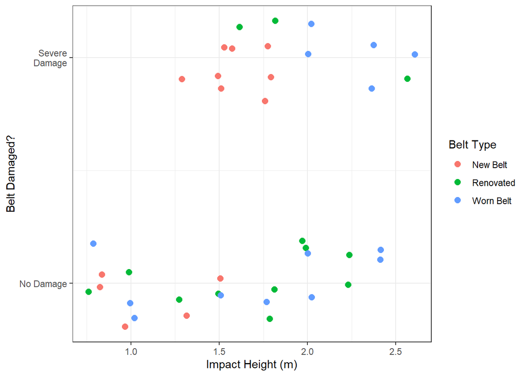

```r
ggplot(belt_data, aes(x=Height, y=Damaged, color=Belt_type) ) +
  geom_jitter(height=0.2, size=2.4 ) +
  scale_y_continuous(breaks=c(0,1), labels=c("No Damage", "Severe\nDamage") ) +
  labs(x="Impact Height (m)",
       y="Belt Damaged?",
       color="Belt Type") +
  theme_bw()
```

From the table and plot we can gain some insight.

- For the “New” belts (in red in the plot), we can see the eight cases of severe damage occur at higher impact heights than the five that did not record severe damage.
- For “Renovated” belts there are only three cases of severe damage.
- The “Worn” belts have five cases of severe damage and all at high values of impact heights.

It is not perfectly clear, but it does appear there are more cases of severe damage at higher impact heights (it makes sense based on physics). It is also not perfectly clear how the three belt types differ, although it does appear new belts may sustain severe damage at lower impact heights.

## Logistic Model

From the description of the experimental design, we are interested in determining if the factor variable predicts the likelihood of severe damage after accounting for a covariate term, and the covariate term is considered a *known* (or suspected known) effect. This is similar to a One-Way Block design; we will use a main effects structure in our model.

```r
belt_fit_model <- glm(Damaged ~ Belt_type + Height,
                      data=belt_data,
                      family=binomial(link=logit))
```

First, we will determine if the model is significantly predicting the likelihood of severe damage.

```r
belt_fit_null <- glm(Damaged ~ 1,
                     data=belt_data,
                     family=binomial(link=logit))
anova(belt_fit_null, belt_fit_model)
```

```
Analysis of Deviance Table

Model 1: Damaged ~ 1
Model 2: Damaged ~ Belt_type + Height
  Resid. Df Resid. Dev Df Deviance  Pr(>Chi)
1        39     53.841
2        36     36.871  3    16.97 0.0007168 ***
---
Signif. codes:  0 '***' 0.001 '**' 0.01 '*' 0.05 '.' 0.1 ' ' 1
```

With a $\chi^2$ value of 16.97 on 3 degrees of freedom ($p$-value = 0.0007168), we have evidence that some combination of belt type and impact height of the drop hammer predict the likelihood a conveyor belt sustains severe damage.

We also note this model explains about $(1 - 36.871/53.841)\times 100\%$ = 31.52 percent of the deviance in the proportion of belts sustaining severe damage.

Just as importantly the ratio of the residual deviance to its degrees of freedom is $36.871/36 = 1.024 \approx 1$ which indicates a good fit, validating the logistic model.

## Testing Key Hypothesis

The key question is whether there is a difference in the three belt types after accounting for the impact height of the drop hammer. Back when covering experimental design, we would look at an ANOVA table. Since we have a main-effects logistic model we will perform Likelihood Ratio Test using the `drop1()` function. This provides the hypothesis test needed here.

```r
drop1(belt_fit_model, test="LRT")
```

```
Single term deletions

Model:
Damaged ~ Belt_type + Height
          Df Deviance    AIC    LRT  Pr(>Chi)
<none>         36.871 44.871
Belt_type  2   49.182 53.182 12.311 0.0021215 **
Height     1   49.618 55.618 12.747 0.0003566 ***
---
Signif. codes:  0 '***' 0.001 '**' 0.01 '*' 0.05 '.' 0.1 ' ' 1
```

With a $\chi^2 = 12.311$ on 2 degrees of freedom, $p$-value = 0.00212, we have significant evidence to suggest the belt type predicts whether a belt is severely damaged in the test.

**Note**

Recall from the Design of Experiments module, we are not all that interested in statistically testing *block* type effects. Here, physics tells us impact height should be influential! It is essentially a *known effect*, similar to a block term. The Likelihood Ratio Test for `Height` essentially confirms the results of Sir Isaac Newton.

## Model Interpretation

Take a look at the model coefficients:

```r
summary(belt_fit_model)
```

```
Call:
glm(formula = Damaged ~ Belt_type + Height, family = binomial(link = logit),
    data = belt_data)

Coefficients:
                   Estimate Std. Error z value Pr(>|z|)
(Intercept)          -4.612      1.986  -2.323  0.02020 *
Belt_typeRenovated   -3.649      1.336  -2.731  0.00632 **
Belt_typeWorn Belt   -3.555      1.438  -2.472  0.01344 *
Height                3.691      1.360   2.715  0.00663 **
---
Signif. codes:  0 '***' 0.001 '**' 0.01 '*' 0.05 '.' 0.1 ' ' 1

(Dispersion parameter for binomial family taken to be 1)

    Null deviance: 53.841  on 39  degrees of freedom
Residual deviance: 36.871  on 36  degrees of freedom
AIC: 44.871

Number of Fisher Scoring iterations: 5
```

We briefly review material from the previous lectures. The goal is to model
$$p = P(\textrm{Severe Damage Occured}).$$

We model $p$ with a logistic regression; therefore we model the log-odds:
$$logit(p) = \log\left(\frac{p}{1-p}\right) = \hat{\beta}_0 + \hat{\beta}_1 I(\text{Renovated}) + \hat{\beta}_2 I(\text{Worn}) + \hat{\beta}_3 \text{Height}$$
Which can be rewritten in terms of odds:
$$\frac{p}{1-p} = \exp\left\{\hat{\beta}_0\right\} \times \exp\left\{\hat{\beta}_1 I(\text{Renovated})\right\} \times \exp\left\{\hat{\beta}_2 I(\text{Worn})\right\} \times \exp\left\{\hat{\beta}_3 \text{Height}\right\}$$

With respect to the probability $p$, the model can be re-written as
$$p = \frac{\exp\left\{\hat{\beta}_0 + \hat{\beta}_1 I(\text{Renovated}) + \hat{\beta}_2 I(\text{Worn}) + \hat{\beta}_3 \text{Height}\right\}}{1 + \exp\left\{\hat{\beta}_0 + \hat{\beta}_1 I(\text{Renovated}) + \hat{\beta}_2 I(\text{Worn}) + \hat{\beta}_3 \text{Height}\right\}}$$

The model includes the following terms:

- `(Intercept)` corresponds to a “New” belt with an impact height of the drop hammer at 0 meters.
  - The log odds of severe damage are -4.612.
  - The odds of severe damage are 0.01.
- `Belt_typeRenovated` represents the change in log-odds when switching the belt type from “New” to “Renovated”.
  - The log odds of severe damage will decease by 3.649 units.
  - The odds of severe damage will change by a multiplicative factor of 0.026 (note this value is less than 1).
  - That is, the odds of severe damage will decrease by 97.4 percent.
- `Belt_typeWorn Belt` corresponds to the change in log-odds when switching the belt type from “New” to “Worn”.
  - The log odds of severe damage will decease by 3.555 units.
  - The odds of severe damage will change by a multiplicative factor of 0.029.
  - That is, the odds of severe damage will decrease by 97.1 percent.
  - Note the changes from “New” to “Renovated” and “New” to “Worn” are similar in magnitude.
- `Height` corresponds to the change in log-odds of severe damage when the impact height increases by 1 unit (meter).
  - For every one meter increase in height of the drop hammer, we expect the log odds to increase by 3.691 units.
  - The odds of severe damage will increase by a factor of 40.093 for every one meter increase in drop hammer height.
  - For every one meter increase in drop hammer height, we expect the odds of severe damage to increase by 3909.3 percent! This is huge but you need to consider the units of the $x$ variable (meters) and that the change is multiplicative.

## Multiple Comparisons

We have determined the following (so far):

- The model with Belt types and heights predicts the probability of severe damage occurring in conveyor belts.
- Both Height and Belt type appear to be significant predictors.
- Based on the EDA and interpretation of our fitted model, it appears the “New” belt type has higher rates of severe damage compared to the “Renovated” and “Worn” belts.
  - We will now formally test how the belts differ.

During our Design of Experiments module, we use the `emmeans` package to perform Tukey and Dunnett multiple comparisons. The `emmeans` package includes functionality that works with GLMs. First, we load the library

```r
library(emmeans)
```

Now, we can set up the comparison of interest

```r
belt_em <- emmeans(belt_fit_model, ~Belt_type)
```

Now, we perform a Tukey multiple comparison (since there is no clear control)

```r
contrast(belt_em, "tukey")
```

```
 contrast              estimate   SE  df z.ratio p.value
 New Belt - Renovated    3.6492 1.34 Inf   2.731  0.0174
 New Belt - Worn Belt    3.5555 1.44 Inf   2.472  0.0358
 Renovated - Worn Belt  -0.0937 1.05 Inf  -0.089  0.9956

Results are given on the log odds ratio (not the response) scale.
P value adjustment: tukey method for comparing a family of 3 estimates
```

We can conclude the following

- “New” belts are statistically different than “Renovated” belts in terms of the log-odds of sustaining severe damage in a drop hammer test after adjusting for impact height.
- “New” belts are also statistically different then “Worn” belts in terms of the log-odds of severe damage.
- “Renovated” and “Worn” belts have similar performance in this test. Specifically, there is no statistical different in the relationship between impact height and the log-odds of sustaining severe damage between these two belt types.

### Working with Transformations

The above `emmeans` results are all in terms of log-odds of severe damage, which is very similar to working in the original units when performing ANOVA. The `emmeans()` function provides functionality that allows us to compare in terms of probabilities. All we need to do is pass along the option `trans="response"`.

Some caveats – look back up at the fitted model equations. To calculate a probability we need a `Height` value. For different values of `Height` we will get a different probability. The `emmeans` function will perform the comparisons at the “average” impact Height, or `mean(belt_data$Height)` = 1.678. Also note that the $p$-values change a little since the comparisons are now made on the difference in probabilities, rather than change in log-odds.

**Note**

Some “fun” Physics notes: at a drop height of 1.678 meters of an 82kg object

- The velocity at the time of impact is $\sqrt{2gh}$ or 5.735 $m/s$ or 12.8mph.
- The hammer will complete its fall in $\sqrt{2h/g}$ or 0.585 seconds.
- Since this is a free-fall ‘drop experiment’, the potential energy and kinetic energy at impact are equal (ignoring air resistance), the energy at impact is is $82\times 9.8\times 1.678 =$ 1348.039 Joules.
  - The energy when stumping your toe is approximated to be between 10 and 15 Joules.
  - Impact on humans often becomes fatal at 100 Joules (depending on the location of impact). Here the impact is more than 12-times greater.

```r
belt_em2 <- emmeans(belt_fit_model, ~Belt_type,
                   trans="response")
contrast(belt_em2, "tukey")
```

```
 contrast              estimate    SE  df z.ratio p.value
 New Belt - Renovated   0.71710 0.160 Inf   4.495 <0.0001
 New Belt - Worn Belt   0.70742 0.176 Inf   4.020  0.0002
 Renovated - Worn Belt -0.00968 0.109 Inf  -0.088  0.9957

P value adjustment: tukey method for comparing a family of 3 estimates
```

We get similar results except now we compare the probabilities. At an impact height of 1.678 the probability of a “New” belt sustaining severe damage is about 70% higher than that or Renovated or Worn belts.

## Conclusions

We finish a complete analysis with a contextual conclusions. Ideally we accompany that conclusion with some graphics or tables that help *tells the story*.

Here, we have conclusive evidence that larger impact heights of a drop hammer will result in higher rates of severe damage in conveyor belts. We also have evidence that “New” conveyor belts are more susceptible to severe damage than “Renovated” or “Worn” conveyor belts.

Using the `emmeans` package we can make a visual that helps tell the story. At an impact height of 1.678 we expect the probability of severe damage to follow the pattern:

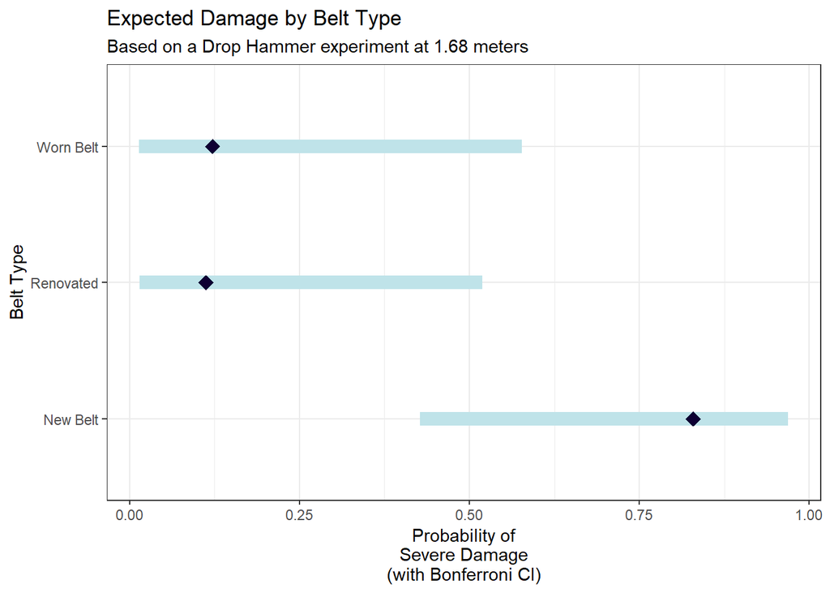

```r
plot(belt_em, type="response", int.adjust="bonferroni") +
  labs(y="Belt Type",
       x="Probability of\nSevere Damage\n(with Bonferroni CI)",
       title="Expected Damage by Belt Type",
       subtitle="Based on a Drop Hammer experiment at 1.68 meters") +
  theme_bw()
```

Here we display the predicted probability of sustaining severe damage at the “average” impact height. The New belts are much more likely to sustain severe damage than the Worn or Renovated belts.

We can also provide a plot of the fitted model (much like we did for the spider cannibalism and youth bullying examples in previous lectures). This provides insight into both variables.

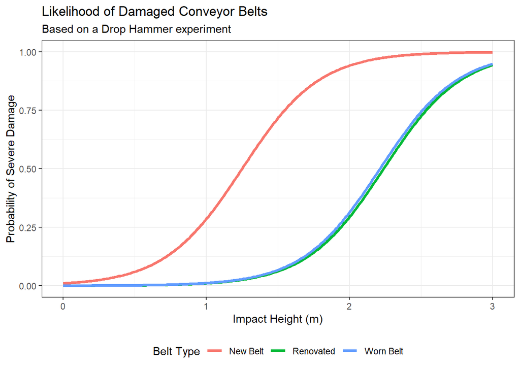

```r
Height_seq <- seq(0, 3, 0.01)
fake_belt_df <- data.frame(
  Belt_type = rep(c("New Belt", "Renovated", "Worn Belt"), each=length(Height_seq) ),
  Height = rep(Height_seq, 3)
)

fake_belt_df <- fake_belt_df |>
  mutate(Prob = predict(belt_fit_model, newdata=fake_belt_df, type="response"))

ggplot(fake_belt_df, aes(x=Height, y=Prob, color=Belt_type) ) +
  geom_line(linewidth=1.25) +
  labs(x="Impact Height (m)",
       y="Probability of Severe Damage",
       title="Likelihood of Damaged Conveyor Belts",
       subtitle="Based on a Drop Hammer experiment",
       color="Belt Type") +
  theme_bw() +
  theme(legend.position="bottom")
```

The plot shows the probability of sustaining severe damage increases with the impact height (as expected), but we also see that New Belts generally have a higher probability as compared to the Renovated and Worn belts. The plotted lines for the Renovated and Worn belts are practically the same (this should make sense based on the multiple comparisons findings).

**Note**

In the fitted model, all the three belts share the same slope (the coefficient on Height is constant across all three belt types). A difference in the intercept essentially dictates where the “S-curve” starts to make its turn, not the magnitude of the increase.

**Coding Note**

We could include confidence bands in this plot as we did in Logistic Lecture 03. We have excluded them here as it add *visual clutter* to the plot.

## References

Andrejiova, Miriam, Anna Grincova, Daniela Marasova, Gabriel Fedorko, and Vieroslav Molnar. 2014. “Using Logistic Regression in Tracing the Significance of Rubber–Textile Conveyor Belt Damage.” *Wear* 318 (1): 145–52. https://doi.org/10.1016/j.wear.2014.06.026.